# IDP meta-analysis of TSPO in psychosis: the sequal

Pontus Plavén-Sigray

13/11/2019

# Descriptive data

Table below displays the demographic data of the included studies.

Descriptive data of all included studies. DOI, duration of illness; HABs, high-affinity binders; HCs, healthy control subjects; MABs, mixed-affinity binders; PANSS-N, PANSS–Negative score; PANSS-P, PANSS–Positive score; Pat, participants with psychosis or schizophrenia.

Diagnostic group

Schizophrenia / Other*

Age Years Mean (SD)

Count

HABs

MABs

Men

Women

PANSS-P Mean (SD)

PANSS-N Mean (SD)

DOI Months Mean (SD)

Drug free Total

Radioligand

**Collste et al.**

HC

26.38 (8.44)

16

9

7

7

9

[11C]PBR28

Pat

4/12

28.50 (8.37)

16

8

8

11

5

20.3 (4.9)

18.1 (7.0)

7.9 (9.6)

16/16

[11C]PBR28

**Laurikainen et al.**

HC

29.7 (7.45)

15

9

6

5

10

[11C]PBR28

Pat

4/9

24.8 (4.00)

13

8

5

7

6

3.9 (3.4)

2/13

[11C]PBR28

**Coughlin et al.**

HC

25.36 (4.89)

14

9

5

9

5

[11C]DPA173

Pat

12/0

24.33 (3.28)

12

8

4

9

3

13.8 (2.7)

15.8 (4.6)

25.0 (16.3)

2/12

[11C]DPA173

**Hafizi et al.**

HC

27.17 (9.07)

18

14

4

8

10

[18F]FEPPA

Pat

15/4

27.53 (6.78)

19

14

5

12

7

19.2 (3.8)

16.1 (6.1)

33.6 (40.1)

19/19

[18F]FEPPA

**Bloomfield et al.**

HC

46.21 (13.62)

14

14

0

11

3

[11C]PBR28

Pat

12/0

47.00 (9.31)

12

12

0

9

3

17.0 (6.1)

14.1 (4.0)

108.9 (46.7)

0/12

[11C]PBR28

**Kenk et al.**

HC

54.27 (9.51)

15

10

5

7

8

[18F]FEPPA

Pat

16/0

42.50 (14.03)

16

10

6

10

6

19.3 (2.2)

18.6 (5.0)

177.3 (105.7)

0/16

[18F]FEPPA

**Ottoy et al.**

HC

27.1 (5.69)

15

6

9

15

0

[18F]PBR111

Pat

11/0

30.6 (7.65)

11

6

5

11

0

24.3 (5.6)

17.4 (7.3)

62.2 (96.1)

1/11

[18F]PBR111

**All**

HC

33.5 (13.6)

107

71

36

62

45

Pat

74/25

32.4 (11.7)

99

66

33

69

30

19.8 (4.9)

16.8 (5.8)

65.9 (87.1)

40/99

*For Collste et al. (1) other diagnoses were: 7 schizophreniform disorder, 4 psychosis not otherwise specified, and 1 brief psychosis. For Hafizi et al. (2) other diagnoses were: 3 schizophreniform and 1 delusional disorder. For Laurikainen et al. (3) other diagnoses were: 2 schizophreniform disorder, 4 psychosis not otherwise specified, 2 Major depressive episode, severe with psychotic features and 1 Bipolar disorder, manic episode, severe with psychotic features.

**Laurikainen et al. (3) used the Brief Psychiatric Rating Scale (BPRS) for assessing symptom severity. The BPRS positive mean symptom scale scores were 17.8 (SD = 7.1), and BPRS mean negative symptom scale scores were 17.0 (SD = 6.4) for patients.

Fourteen healthy-control subjects were shared across two of the original studies (2, 4). In this meta-analysis, healthy control subjects from these two studies have been uniquely assigned to either one of the studies, so that no subject’s V<sub>T</sub> value appears more than once in the statistical models. Assignment was done as to best match the patient groups based on count, genotype, gender, and age.

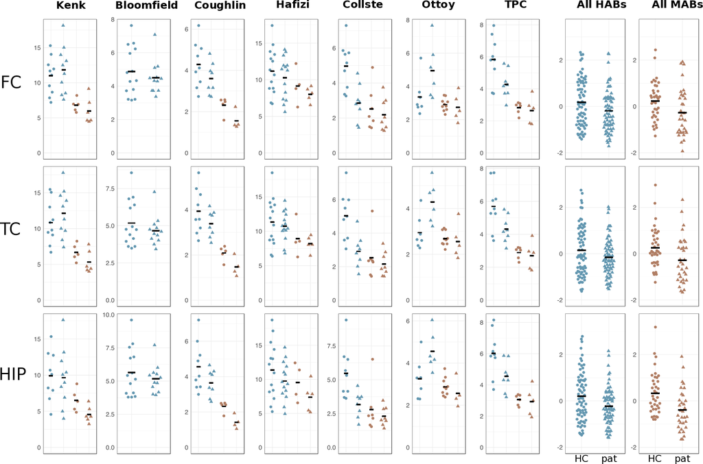

All raw VT values from all studies included in the meta-analysis

Data from all included studies. The the right most panel data for all HABs and MABs have been pooled. VT values have been z-scored (mean set to 0 and SD set to 1) within each genotype group to allow for visualization.

# Hypotheses testing

Three hypotheses were examined:

- H0: No difference in V<sub>T</sub> between patients and controls
- H1: Patients have higher V<sub>T</sub> as compared to controls
- H2: Patients have lower V<sub>T</sub> as compared to controls

## Frequentist stats

Results from LME model including only genotype as covariate:

| Region | Estimate | SE | t | df | p |
| --- | --- | --- | --- | --- | --- |
| FC | -0.41 | 0.13 | -3.11 | 205 | 0.0022 |
| TC | -0.38 | 0.13 | -2.85 | 205 | 0.0048 |
| HIP | -0.53 | 0.13 | -4.02 | 203 | 0.0001 |

Results from LME model including genotype as covariate and age and sex as additional predictors:

| Region | Estimate | SE | t | df | p |
| --- | --- | --- | --- | --- | --- |
| **Patient-Control status** |  |  |  |  |  |
| FC | -0.37 | 0.13 | -2.82 | 203 | 0.0053 |
| TC | -0.34 | 0.13 | -2.60 | 203 | 0.0101 |
| HIP | -0.50 | 0.13 | -3.79 | 201 | 0.0002 |
| **Age** |  |  |  |  |  |
| FC | 0.00 | 0.07 | -0.06 | 203 | 0.9488 |
| TC | -0.01 | 0.07 | -0.11 | 203 | 0.9120 |
| HIP | -0.03 | 0.07 | -0.38 | 201 | 0.7080 |
| **Sex** |  |  |  |  |  |
| FC | -0.37 | 0.14 | -2.70 | 203 | 0.0076 |
| TC | -0.31 | 0.14 | -2.24 | 203 | 0.0259 |
| HIP | -0.28 | 0.14 | -2.08 | 201 | 0.0392 |

When controlling for sex and age, patient-control status remain a significant predictor for VT in all three regions. Hence, lower VT in patients does not appear to be explained by either of these two variables. VT is significantly lower in males compared to females.

## Bayes factor

BF10 - Higher in patients v.s. no difference; BF20 - Lower in patients v.s. no difference; BF12 - Higher in patients v.s. lower in patients

| Region | BF10 | BF01 | BF20 | BF02 | BF12 | BF21 |
| --- | --- | --- | --- | --- | --- | --- |
| FC | 0.13 | 7.73 | 8.28 | 0.12 | 0.02 | 64.01 |
| TC | 0.16 | 6.39 | 5.03 | 0.20 | 0.03 | 32.11 |
| HIP | 0.16 | 6.26 | 24.12 | 0.04 | 0.01 | 150.98 |

The Bayes Factors show that there is strong evidence in data for the hypothesis that patients have lower VT than HC in all three regions, compared to patients having higher VT than HC.

# Parameter estimation

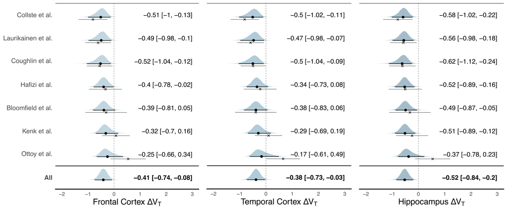

The overall effect suggest that patients have lower VT in all three regions compared to controls. The posterior distributions are centered around what is commonly interpreted as a “medium” sized effect. The 95% credible intervals does however indicate that the uncertainty of the overall effect range from a negligible effect (i.e. a Cohen’s D close to 0) to a large effect (i.e. a Cohen’s D close to 1).

# Secondary analyses

## Effect of medication

| Region | Estimate | SE | t | df | p |
| --- | --- | --- | --- | --- | --- |
| **Patient-control status** |  |  |  |  |  |
| FC | -0.37 | 0.13 | -2.82 | 203 | 0.0053 |
| TC | -0.34 | 0.13 | -2.60 | 203 | 0.0101 |
| HIP | -0.50 | 0.13 | -3.79 | 201 | 0.0002 |
| **medication status** |  |  |  |  |  |
| FC | 0.10 | 0.20 | 0.50 | 204 | 0.6151 |
| TC | 0.08 | 0.20 | 0.43 | 204 | 0.6658 |
| HIP | 0.08 | 0.19 | 0.41 | 202 | 0.6822 |

When adding anti-psychotic medication-status (medicated or non-medicated) as predictor, it shows no significant association to VT in any of the three regions. Patient-control status also remains a significant predictor of VT.

## Symptom severity

Association between VT and PANSS-Positive (or equivalent) and PANSS-Negative (or equivalent) in all three regions.

| Region | Estimate | SE | t | df | p |
| --- | --- | --- | --- | --- | --- |
| **PANSS-Positive** |  |  |  |  |  |
| FC | 0.05 | 0.09 | 0.55 | 110.00 | 0.5844 |
| TC | 0.05 | 0.09 | 0.61 | 102.67 | 0.5437 |
| HIP | 0.01 | 0.08 | 0.06 | 104.88 | 0.9490 |
| **PANSS-Negative** |  |  |  |  |  |
| FC | -0.01 | 0.09 | -0.09 | 110.00 | 0.9259 |
| TC | 0.02 | 0.09 | 0.18 | 102.49 | 0.8610 |
| HIP | -0.01 | 0.08 | -0.11 | 104.75 | 0.9104 |

There is no significant association between VT and PANSS-Positive or PANSS-Negative scores in any of the three regions.

## Duration of illness

| Region | Estimate | SE | t | df | p |
| --- | --- | --- | --- | --- | --- |
| FC | 0.06 | 0.10 | 0.64 | 96.00 | 0.5269 |
| TC | 0.05 | 0.09 | 0.51 | 10.45 | 0.6212 |
| HIP | 0.01 | 0.09 | 0.15 | 95.00 | 0.8824 |

There is no significant association between VT and duration of illness in any of the three regions.

# Exploratory analyses

The following analyses were not part of the pre-registration, and performed after seeing the results of the analyses above.

## Age-Group interaction effect

Results from LME model including genotype as covariate and a patient-control status v.s. age interaction effect:

| Region | Estimate | SE | t | df | p |
| --- | --- | --- | --- | --- | --- |
| **Patient-Control status** |  |  |  |  |  |
| FC | -0.37 | 0.13 | -2.81 | 202 | 0.0054 |
| TC | -0.34 | 0.13 | -2.59 | 202 | 0.0103 |
| HIP | -0.50 | 0.13 | -3.79 | 200 | 0.0002 |
| **Patient-Control status Age interaction** |  |  |  |  |  |
| FC | 0.06 | 0.13 | 0.46 | 202 | 0.6438 |
| TC | 0.00 | 0.14 | 0.03 | 202 | 0.9723 |
| HIP | -0.04 | 0.13 | -0.31 | 200 | 0.7600 |

The patient-control status to age-interaction was not significant, indicating no differential age effect on patients’ and controls’ VT values in any of the three regions of interest.

## Sex-Group interaction effect

Results from LME model including genotype as covariate and a patient-control status v.s. sex interaction effect:

| Region | Estimate | SE | t | df | p |
| --- | --- | --- | --- | --- | --- |
| **Patient-Control status** |  |  |  |  |  |
| FC | -0.50 | 0.22 | -2.27 | 203 | 0.0243 |
| TC | -0.52 | 0.22 | -2.31 | 203 | 0.0218 |
| HIP | -0.79 | 0.22 | -3.60 | 201 | 0.0004 |
| **Patient-Control status Sex interaction** |  |  |  |  |  |
| FC | 0.20 | 0.28 | 0.74 | 203 | 0.4594 |
| TC | 0.27 | 0.28 | 0.96 | 203 | 0.3398 |
| HIP | 0.45 | 0.27 | 1.66 | 201 | 0.0981 |

The patient-control status to sex-interaction was not significant, indicating no differential sex effect on patients’ and controls’ VT values in any of the three regions of interest.

# References

1. Collste K, Plavén-Sigray P, Fatouros-Bergman H, Victorsson P, Schain M, Forsberg A *et al.* (2017): Lower levels of the glial cell marker TSPO in drug-naive first-episode psychosis patients as measured using PET and [11C]PBR28. *Molecular Psychiatry*. 22: 850–856.

2. Hafizi S, Da Silva T, Gerritsen C, Kiang M, Bagby RM, Prce I *et al.* (2017): Imaging Microglial Activation in Individuals at Clinical High Risk for Psychosis: an In Vivo PET Study with [(18) F] FEPPA. *Neuropsychopharmacology: official publication of the American College of Neuropsychopharmacology*. 174: 118–124.

3. Laurikainen H, Vuorela A, Toivonen A, Reinert-Hartwall L, Trontti K, Lindgren M *et al.* (2020): Elevated serum chemokine CCL22 levels in first-episode psychosis: associations with symptoms, peripheral immune state and in vivo brain glial cell function. *Translational psychiatry*. In press.

4. Kenk M, Selvanathan T, Rao N, Suridjan I, Rusjan P, Remington G *et al.* (2015): Imaging neuroinflammation in gray and white matter in schizophrenia: an in-vivo PET study with [18F]-FEPPA. *Schizophrenia bulletin*. 41: 85–93.